# Senti540_RM

```
import pandas as pd

import os
import string
from string import digits
import re

import unicodedata
```

```
#Import the Jobs.csv file
from google.colab import files
uploaded = files.upload()
```

Saving Mental-Health-Twitter.csv to Mental-Health-Twitter (1).csv

<IPython.core.display.HTML object>

[interactive chart not shown]

```
mhealth = pd.read_csv('Mental-Health-Twitter.csv', encoding = 'utf8')
```

```
##print first 5 rows

mhealth = mhealth.drop('Unnamed: 0', axis =1)
mhealth.head()
```

post_id post_created \  
0 6.378950e+17 Sun Aug 30 07:48:37 +0000 2015  
1 6.378900e+17 Sun Aug 30 07:31:33 +0000 2015  
2 6.377490e+17 Sat Aug 29 22:11:07 +0000 2015  
3 6.376960e+17 Sat Aug 29 18:40:49 +0000 2015  
4 6.376960e+17 Sat Aug 29 18:40:26 +0000 2015  
post_text user_id followers \  
0 It's just over 2 years since I was diagnosed w... 1.013187e+09 84  
1 It's Sunday, I need a break, so I'm planning t... 1.013187e+09 84  
2 Awake but tired. I need to sleep but my brain ... 1.013187e+09 84  
3 RT @SewHQ: #Retro bears make perfect gifts and... 1.013187e+09 84  
4 It’s hard to say whether packing lists are mak... 1.013187e+09 84  
friends favourites statuses retweets label  
0 211 251 837 0 1  
1 211 251 837 1 1  
2 211 251 837 0 1  
3 211 251 837 2 1  
4 211 251 837 1 1

[interactive chart not shown]

```
mhealth.isnull().sum() ##no missing 'values'
```

post_id 0  
post_created 0  
post_text 0  
user_id 0  
followers 0  
friends 0  
favourites 0  
statuses 0  
retweets 0  
label 0  
dtype: int64

[interactive chart not shown]

```
mhealth = mhealth[['post_text', 'favourites', 'retweets']]
mhealth.head() #neccesary columns
```

[interactive chart not shown]

```
!pip install textblob

from textblob import TextBlob
from textblob import Word
```

```
#Lowercase
mhealth['post_text'] = mhealth['post_text']=mhealth['post_text'].str.lower()

# Remove punctuations and numbers
mhealth['post_text'] = mhealth['post_text'].str.replace(r'[^\w\s]','', regex = True)

mhealth['post_text'] = mhealth['post_text'].str.replace(r'\brt\b', '', regex = True,  case=False) ##remove rt as per correction on A2540

mhealth['post_text'] = mhealth['post_text'].str.replace('\d+', '', regex = True)
mhealth['post_text'].head(5)
```

0 its just over years since i was diagnosed wit...  
1 its sunday i need a break so im planning to sp...  
2 awake but tired i need to sleep but my brain h...  
3 sewhq retro bears make perfect gifts and are ...  
4 its hard to say whether packing lists are maki...  
Name: post_text, dtype: object

[interactive chart not shown]

```
import nltk
nltk.download('stopwords')
from nltk.corpus import stopwords
print(stopwords.words('english'))
```

['i', 'me', 'my', 'myself', 'we', 'our', 'ours', 'ourselves', 'you', "you're", "you've", "you'll", "you'd", 'your', 'yours', 'yourself', 'yourselves', 'he', 'him', 'his', 'himself', 'she', "she's", 'her', 'hers', 'herself', 'it', "it's", 'its', 'itself', 'they', 'them', 'their', 'theirs', 'themselves', 'what', 'which', 'who', 'whom', 'this', 'that', "that'll", 'these', 'those', 'am', 'is', 'are', 'was', 'were', 'be', 'been', 'being', 'have', 'has', 'had', 'having', 'do', 'does', 'did', 'doing', 'a', 'an', 'the', 'and', 'but', 'if', 'or', 'because', 'as', 'until', 'while', 'of', 'at', 'by', 'for', 'with', 'about', 'against', 'between', 'into', 'through', 'during', 'before', 'after', 'above', 'below', 'to', 'from', 'up', 'down', 'in', 'out', 'on', 'off', 'over', 'under', 'again', 'further', 'then', 'once', 'here', 'there', 'when', 'where', 'why', 'how', 'all', 'any', 'both', 'each', 'few', 'more', 'most', 'other', 'some', 'such', 'no', 'nor', 'not', 'only', 'own', 'same', 'so', 'than', 'too', 'very', 's', 't', 'can', 'will', 'just', 'don', "don't", 'should', "should've", 'now', 'd', 'll', 'm', 'o', 're', 've', 'y', 'ain', 'aren', "aren't", 'couldn', "couldn't", 'didn', "didn't", 'doesn', "doesn't", 'hadn', "hadn't", 'hasn', "hasn't", 'haven', "haven't", 'isn', "isn't", 'ma', 'mightn', "mightn't", 'mustn', "mustn't", 'needn', "needn't", 'shan', "shan't", 'shouldn', "shouldn't", 'wasn', "wasn't", 'weren', "weren't", 'won', "won't", 'wouldn', "wouldn't"]

```
stopwords = stopwords.words('english')
```

```
def remove_stopwords(text):
#    return ' '.join([word for word in text.split() if word not in stopwords])
    return ' '.join(word for word in text.split() if word not in stopwords)
```

```
# stopwords
mhealth['post_text'] = mhealth['post_text'].apply(remove_stopwords)
```

```
!pip install spacy
!python -m spacy download en_core_web_sm


import spacy
nlp = spacy.load('en_core_web_sm')
```

```
##Lemmatize

mhealth['post_text'] = mhealth['post_text'].apply(lambda row: " ".join([w.lemma_ for w in nlp(row)]))
mhealth['post_text'].head(3)
```

0 year since diagnose anxiety depression today I...  
1 sunday need break I m plan spend little time p...  
2 awake tired need sleep brain idea  
Name: post_text, dtype: object

[interactive chart not shown]

# **Sentiment Analysis**

```
!pip install vaderSentiment textblob
```

```
mhealth = mhealth.iloc[:10000]
```

```
import vaderSentiment
from vaderSentiment.vaderSentiment import SentimentIntensityAnalyzer
```

```
analyzer = SentimentIntensityAnalyzer()
for i in range(len(mhealth.index)):
    vs = analyzer.polarity_scores(mhealth.loc[i, 'post_text'])
    mhealth.loc[i, 'vader_pos'] = vs['pos']
    mhealth.loc[i, 'vader_neg'] = vs['neg']
    mhealth.loc[i, 'vader_neu'] = vs['neu']
    mhealth.loc[i, 'vader_compound'] = vs['compound']

mhealth
```

post_text favourites retweets \  
0 year since diagnose anxiety depression today I... 251 0  
1 sunday need break I m plan spend little time p... 251 1  
2 awake tired need sleep brain idea 251 0  
3 sewhq retro bear make perfect gift great begin... 251 2  
4 hard say whether pack list make life easy rein... 251 1  
... ... ... ...  
9995 cslewisu agree forgiveness beautiful idea prac... 664 217  
9996 can not believe year blastyblast wlmhk picstit... 664 0  
9997 one year ago journey begin never know challeng... 664 0  
9998 find new hammocking friend park today get to s... 664 0  
9999 xanabby you ll grow like 664 0  
vader_pos vader_neg vader_neu vader_compound  
0 0.000 0.278 0.722 -0.6597  
1 0.000 0.000 1.000 0.0000  
2 0.000 0.367 0.633 -0.4404  
3 0.562 0.000 0.438 0.9337  
4 0.171 0.182 0.647 0.2023  
... ... ... ... ...  
9995 0.680 0.000 0.320 0.8176  
9996 0.000 0.000 1.000 0.0000  
9997 0.205 0.087 0.708 0.3975  
9998 0.211 0.000 0.789 0.4939  
9999 0.385 0.000 0.615 0.3612  
[10000 rows x 7 columns]

[interactive chart not shown]

# **Comparison to Metadata**

```
# combined with VADER; average due to mean and vader compound
  # - is the overall or aggregated sentiment score for post_text
# metadata (retweets and favorites)
avgsent_rt = mhealth.groupby('retweets')['vader_compound'].mean()
avgsent_fav = mhealth.groupby('favourites')['vader_compound'].mean()
```

```
##Sentiment by Retweets
print (avgsent_rt)

#Sentiment by Favourites
print(avgsent_fav)
```

retweets  
0 0.009102  
1 0.098602  
2 0.042804  
3 0.095216  
4 -0.045082  
...  
226313 0.752200  
227682 0.029500  
306473 0.718400  
341695 -0.128000  
402946 0.894800  
Name: vader_compound, Length: 879, dtype: float64  
favourites  
0 -0.285409  
1 -0.376071  
3 -0.036817  
10 -0.249500  
11 -0.637800  
14 -0.089248  
29 -0.771700  
33 0.275742  
49 -0.843900  
57 0.042539  
107 -0.046935  
130 0.269539  
154 0.224054  
155 0.198407  
194 0.044462  
221 0.159100  
232 -0.025020  
243 0.129245  
251 0.079467  
280 0.055790  
289 -0.080525  
293 0.079100  
343 0.099956  
365 -0.008169  
451 0.107139  
472 0.044978  
664 0.249418  
698 -0.118440  
757 0.109050  
933 0.258088  
1250 -0.063838  
1807 0.146734  
1926 -0.029911  
2683 0.059762  
2752 0.165707  
3066 -0.029074  
3142 0.241679  
3189 0.308645  
3692 0.100308  
3763 -0.021258  
3786 0.291280  
4301 0.105373  
6920 0.145656  
8276 0.059790  
8375 0.053907  
8717 0.109683  
17720 0.120399  
19320 -0.028763  
32804 0.077730  
39008 0.427245  
Name: vader_compound, dtype: float64

# **Visualization**

```
# Plotting sentiment vs metadata (scatter plots)
plt.figure(figsize=(12, 6)) #good dimensions to fit both plots

# Sentiment vs. Retweets
plt.subplot(1, 2, 1)
plt.scatter(mhealth['retweets'], mhealth['vader_compound'])
plt.xlabel("Retweets")
plt.ylabel("VADER Compound Score")
plt.title("Sentiment vs. Retweets")

# Sentiment vs. Favourites
plt.subplot(1, 2, 2)
plt.scatter(mhealth['favourites'], mhealth['vader_compound'])
plt.xlabel("Favourites")
plt.ylabel("VADER Compound Score")
plt.title("Sentiment vs. Favourites")

plt.tight_layout() #included cause numbers were overlapping in metadata axis
plt.show()
```

<Figure size 1200x600 with 2 Axes>

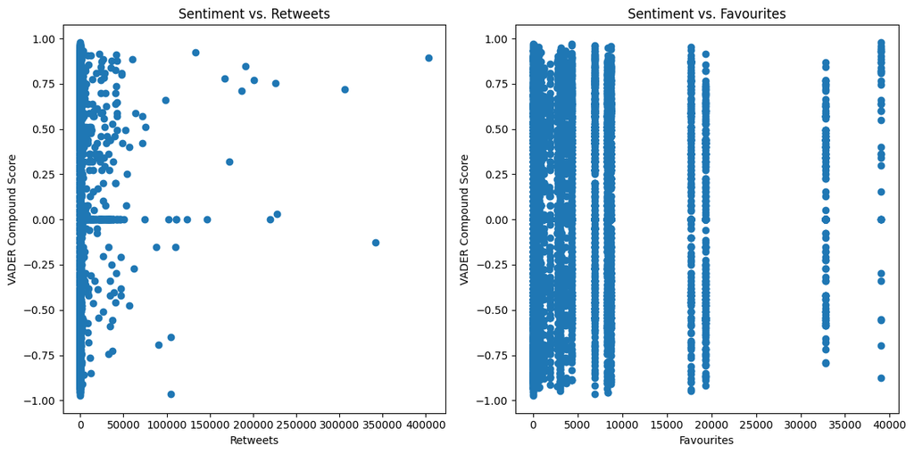

# **Discussion**

**Instruction**

For the dataset you've been using, choose and run the most appropriate sentiment analysis technique or model. Then explain why you think the model you chose is the best for your data and interpret what you learn from the results.

For this sentiment analysis, I decided to use VADER. This type of sentiment analysis is commonly used and quite robust. Apart from other things highlighted in this analysis, I wanted to see if the sentiment score for the posts increases as the number of retweets or favorite increases. Also see what side of sentimentality is it leaning towards (positive, negative, or neutral). Therefore, i combined metadata comparison with my VADER sentiment analysis to get a more insightful information. The plots show how the metadata and vader_compound (overall sentiment score) relate to each other.

**What I learned from this analysis:** Going by overall score (vader_compund), I see that posts usually lean towards negative and postive sentiments, and then some are neutral. The neutral posts do not seem to touch on a specific or personal statement. However, posts surrounding depression, anxiety, exhaustion, or sleep typically leaned towards a more negative sentiment. While, post revolving around overcoming challenges, forgiveness, growth and believe had more positive sentiment. For example a post talking about making gifts has a high positve sentiment score of 0.9337. Just to put in perspective.

0.00 is typically neutral. Any post with a - is negative, especially when close to or exactly -1. By that same reasoning, posts leaning upwards of 0.00 are seen as slightly to complety positve (if close to or is exactly 1).

As for the visualization, both plots showed overlapping data points. It just means that a lot of the retweets and favorites (in their respective plots, have the same overall sentiment scoring or extremely close scores.

The retweet vs sentiment plot shows a lean towards a positive relationship. This may mean that the posts that got higher retweets, also had higher or more positve sentiment scores. I would not say it is generally a strong relationship, but it is slightly positive relationship. The plots also show outliers and overlapping data points. Some of the outliers show that some of the highly retweeted posts had low sentiment scores (negative or slightly negative) and it may indicate that other factors may influence retweets, asides from sentiments. Could be factors such as clarity or how coherent the post it, enough so to get a sense of its sentiment.

For favorites vs sentiment, the plot shows a lot of overlapping data. There are a lot of post favorited that leaned anywhere from positve to neutral to negative. I would say however, the *highest favorited posts* leaned more towards positive sentiments. To me, this plot is less clear. It is possible that other users favorited the posts based on their own personal sentiment. However, the higher the favorites or likes on a post, the more it is more likely to lean away from a total negative sentiment score.

That is to say, people will generally retweet or like more positive posts on social media. However, it depends not only on the sentiment of the posts, but on how the 2nd party (other twitter users) are feeling or if they simply just relate to the posts. Our plots show us that higher retweets tend to have a positive or neutral sentiment, and for favorites it depends; but the higher the number of "likes," the more the sentiment scores leans away from total negative. The printed out sentiment vs metadata scores (not the plots), further confirms my insights.

[figure not shown]